# Where Do International Students Come From — and What Affects Their Enrollment?

Yerkezhan Medetbekova

2025-05-01

## Introduction

Each year, thousands of international students choose to study in the United States. But where do they come from—and what factors influence their enrollment?

As an international student myself, I was curious about how geographic origin, field of study, and academic level affect student numbers over time. I wanted to explore whether certain regions send more students, which academic programs are most common, and how visa types vary over time.

Variable Descriptions

year: The academic year, originally formatted like “2020/21”, separated into start_year and end_year

origin_region: Broad region of origin (e.g., East Asia, Europe)

academic_type: Level of study (e.g., Undergraduate, Graduate)

students: Count of international students per group

field_of_study: Academic field like Engineering, Business, etc.

visa_f, visa_j, visa_other: Number of students by visa type

Through wrangling, visualizations, and modeling, I aim to answer:  
**What factors are associated with international student enrollment in the U.S.?**

In this project, I go through the full data science process: wrangling and cleaning data, creating visualizations, building a linear regression model, and summarizing key insights about what drives international student enrollment in the U.S.

Setup: Loading Packages and Data To begin, I loaded all necessary packages used in this project. I used core functions for data wrangling, visualization, and modeling.

```r
# Load necessary libraries
library(tidyverse)
library(janitor)
library(forcats)
```

Next, I loaded the datasets using `read_csv()` and previewed their structure with `glimpse()`

```r
# Load all related datasets
academic <- read_csv("academic.csv")
academic_detail <- read_csv("academic_detail.csv")
origin <- read_csv("origin.csv")
field_of_study <- read_csv("field_of_study.csv")
source_of_fund <- read_csv("source_of_fund.csv")
status <- read_csv("status.csv")
```

```r
glimpse(origin)
```

```
## Rows: 20,411
## Columns: 5
## $ year          <chr> "2000/01", "2000/01", "2000/01", "2000/01", "2000/01", "…
## $ origin_region <chr> "Africa, Subsaharan", "Africa, Subsaharan", "Africa, Sub…
## $ origin        <chr> "Africa, Subsaharan, Unspecified", "Africa, Subsaharan, …
## $ academic_type <chr> "Graduate", "Other", "Undergraduate", "Graduate", "Other…
## $ students      <dbl> 2, 0, 6, 0, 6, 0, 5, 1, 59, 32, 4, 236, 4, 3, 78, 229, 3…
```

```r
glimpse(field_of_study)
```

```
## Rows: 1,075
## Columns: 4
## $ year           <chr> "1998/99", "1998/99", "1998/99", "1998/99", "1998/99", …
## $ field_of_study <chr> "Agriculture", "Agriculture", "Business and Management"…
## $ major          <chr> "Agriculture", "Natural Resources and Conservation", "B…
## $ students       <dbl> 6146, 1803, 101360, 9473, 1761, 13261, 223, 66264, 5028…
```

```r
glimpse(status)
```

```
## Rows: 16
## Columns: 10
## $ year       <chr> "2007/08", "2008/09", "2009/10", "2010/11", "2011/12", "201…
## $ female     <dbl> 278841, 304242, 309534, 322582, 338671, 363922, 390749, 426…
## $ male       <dbl> 344964, 367374, 381389, 400695, 425824, 455722, 495303, 548…
## $ single     <dbl> 543958, 591694, 615612, 653842, 690339, 744237, 806307, 886…
## $ married    <dbl> 79847, 79922, 75311, 69435, 74156, 75407, 79745, 88718, 929…
## $ full_time  <dbl> 575772, 613185, 637722, 669031, 714038, 769646, 829345, 912…
## $ part_time  <dbl> 48033, 58431, 53201, 54246, 50457, 49998, 56707, 62395, 720…
## $ visa_f     <dbl> 552691, 589007, 612158, 645163, 688810, 747515, 804535, 881…
## $ visa_j     <dbl> 31814, 39625, 38692, 40504, 42047, 42621, 49619, 58496, 521…
## $ visa_other <dbl> 39300, 42984, 40073, 37610, 33638, 29508, 31898, 35097, 344…
```

## Data Wrangling

I worked with three key datasets: origin.csv, field_of_study.csv, and status.csv. Each required parsing the academic year, converting character columns to factors, and aggregating student counts by region, field, or visa type. I used separate() to split the year column into start_year and end_year, mutate() to convert numeric text, and group_by() with summarise() to collapse the data for analysis and plots.

### `origin.csv`

I cleaned the `origin.csv` data by parsing the year, converting variables to factors, filtering for Graduate and Undergraduate students, and grouping by region, academic type, and year.

```r
# Clean and summarize origin data by region and academic type
origin_clean <- origin |>
  separate(year, into = c("start_year", "end_year"), sep = "/", remove = FALSE) |> # Split year column into start and end
  mutate(
    start_year = parse_number(start_year),               # Convert start_year to numeric
    academic_type = factor(academic_type),               # Convert academic_type to factor
    origin_region = factor(origin_region)                # Convert origin_region to factor
  ) |>
  filter(academic_type %in% c("Graduate", "Undergraduate")) |> # Keep only relevant academic types
  group_by(start_year, origin_region, academic_type) |>  # Group by year, region, and type
  summarise(
    students = sum(students, na.rm = TRUE),              # Total students in each group
    .groups = "drop"
  )
origin_clean
```

```
## # A tibble: 866 × 4
##    start_year origin_region      academic_type students
##         <dbl> <fct>              <fct>            <dbl>
##  1       2000 Africa, Subsaharan Graduate             2
##  2       2000 Africa, Subsaharan Undergraduate        6
##  3       2000 Asia               Graduate             0
##  4       2000 Asia               Undergraduate        0
##  5       2000 Caribbean          Graduate          2568
##  6       2000 Caribbean          Undergraduate    12037
##  7       2000 Central Africa     Graduate           375
##  8       2000 Central Africa     Undergraduate     1063
##  9       2000 East Africa        Graduate          2702
## 10       2000 East Africa        Undergraduate     7550
## # ℹ 856 more rows
```

field_of_study.csv I cleaned the field_of_study.csv data by extracting the start year and summarizing total student counts by field and year.

```r
# Prepare field of study data by total students per year

field_clean <- field_of_study |>
  separate(year, into = c("start_year", "end_year"), sep = "/", remove = FALSE) |> # Split year
  mutate(start_year = parse_number(start_year)) |>        # Convert to numeric
  group_by(start_year, field_of_study) |>                 # Group by year and field
  summarise(
    total_students = sum(students, na.rm = TRUE),         # Sum students per field
    .groups = "drop"
  )
field_clean
```

```
## # A tibble: 375 × 3
##    start_year field_of_study                    total_students
##         <dbl> <chr>                                      <dbl>
##  1       1998 Agriculture                                 7949
##  2       1998 Business and Management                   101360
##  3       1998 Communications and Journalism              11234
##  4       1998 Education                                  13261
##  5       1998 Engineering                                73014
##  6       1998 Fine and Applied Arts                      31486
##  7       1998 Health Professions                         20260
##  8       1998 Humanities                                 16295
##  9       1998 Intensive English                          21030
## 10       1998 Legal Studies and Law Enforcement           5403
## # ℹ 365 more rows
```

status.csv I cleaned the status.csv data by separating the year and converting start_year to numeric for future use in plots

```r
# Clean status data

status_clean <- status |>
  separate(year, into = c("start_year", "end_year"), sep = "/", remove = FALSE) |> # Split year
  mutate(start_year = parse_number(start_year)) # Convert start_year to numeric
status_clean
```

```
## # A tibble: 16 × 12
##    year    start_year end_year female   male  single married full_time part_time
##    <chr>        <dbl> <chr>     <dbl>  <dbl>   <dbl>   <dbl>     <dbl>     <dbl>
##  1 2007/08       2007 08       278841 344964  543958   79847    575772     48033
##  2 2008/09       2008 09       304242 367374  591694   79922    613185     58431
##  3 2009/10       2009 10       309534 381389  615612   75311    637722     53201
##  4 2010/11       2010 11       322582 400695  653842   69435    669031     54246
##  5 2011/12       2011 12       338671 425824  690339   74156    714038     50457
##  6 2012/13       2012 13       363922 455722  744237   75407    769646     49998
##  7 2013/14       2013 14       390749 495303  806307   79745    829345     56707
##  8 2014/15       2014 15       426043 548883  886208   88718    912531     62395
##  9 2015/16       2015 16       451982 591857  950937   92902    971814     72025
## 10 2016/17       2016 17       470366 608456  970940  107882   1007620     71202
## 11 2017/18       2017 18       477329 617463  999545   95247   1028010     66782
## 12 2018/19       2018 19       480836 614463 1002199   93100   1030676     64623
## 13 2019/20       2019 20       477520 597976  987305   88191   1016344     59152
## 14 2020/21       2020 21       407686 506409  827256   86839    843710     70385
## 15 2021/22       2021 22       428731 519788  861255   87264    884020     64499
## 16 2022/23       2022 23       473620 583568  966270   90918    986356     70832
## # ℹ 3 more variables: visa_f <dbl>, visa_j <dbl>, visa_other <dbl>
```

## Data Visualization

To explore trends in international student enrollment, I created visualizations that highlight changes over time by region and field of study. These plots help answer where most students come from and what areas they study.

📊 1. Line Plot: Students by Region Over Time

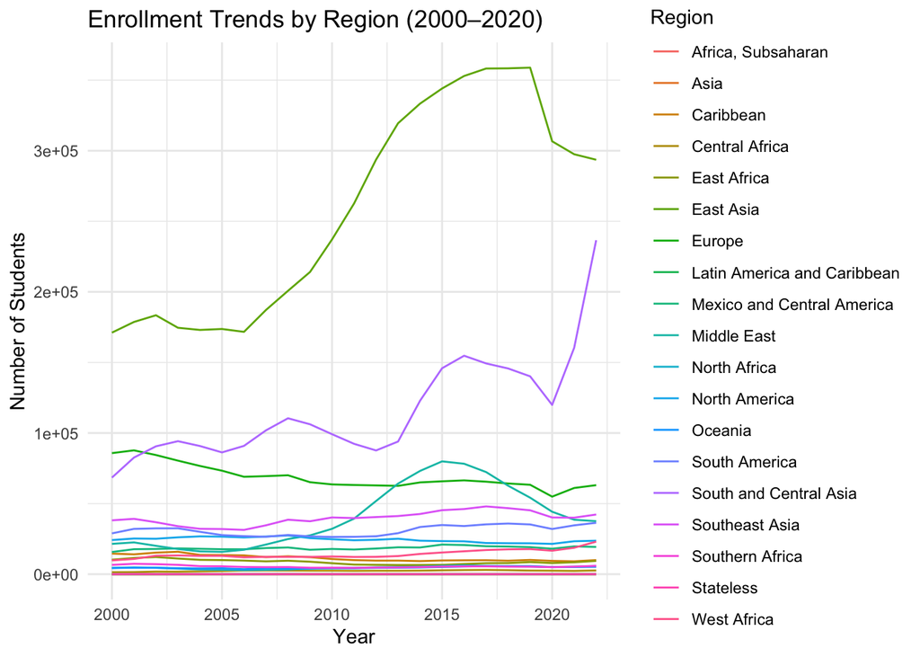

```r
origin_clean |>
  group_by(start_year, origin_region) |>
  summarise(total_students = sum(students, na.rm = TRUE), .groups = "drop") |>
  ggplot(aes(x = start_year, y = total_students, color = origin_region)) +
  geom_line() +
  labs(title = "Enrollment Trends by Region (2000–2020)",
       x = "Year",
       y = "Number of Students",
       color = "Region") +
  theme_minimal()
```

📊 2. Bar Plot: Top Fields of Study in Most Recent Year

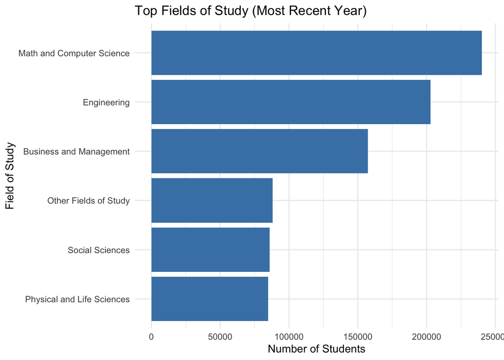

```r
# Filter most recent year and show top 6 fields

field_clean |>
  filter(start_year == max(start_year, na.rm = TRUE)) |>
  slice_max(total_students, n = 6) |>
  ggplot(aes(x = reorder(field_of_study, total_students), y = total_students)) +
  geom_col(fill = "steelblue") +
  coord_flip() +
  labs(
    title = "Top Fields of Study (Most Recent Year)",
    x = "Field of Study",
    y = "Number of Students"
  ) +
  theme_minimal()
```

📌 What it shows: Math & Computer Science, Engineering, and Business are the most popular fields among international students.

📊 3.Line Plot: Visa Type Trends Over Time

This plot compares how different visa types (F, J, and Other) changed across years using status_clean.

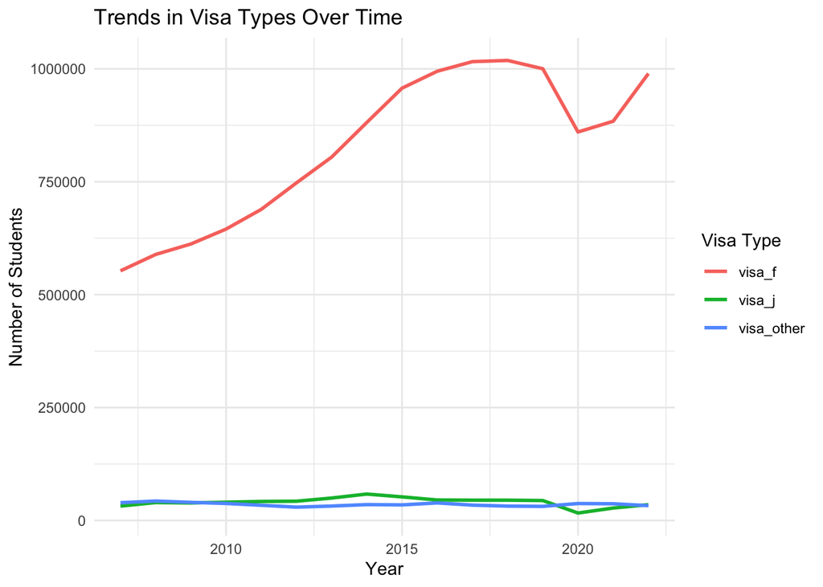

```r
# Reshape visa data into long format for plotting
visa_long <- status_clean |>
  select(start_year, visa_f, visa_j, visa_other) |>
  pivot_longer(
    cols = starts_with("visa"),
    names_to = "visa_type",
    values_to = "students"
  )

# Plot visa type trends
ggplot(visa_long, aes(x = start_year, y = students, color = visa_type)) +
  geom_line(linewidth = 1) +
  labs(
    title = "Trends in Visa Types Over Time",
    x = "Year",
    y = "Number of Students",
    color = "Visa Type"
  ) +
  theme_minimal()
```

📌 What it shows: F-1 visa holders (typical for full-time students) consistently make up the largest group.

J and other visa types are used much less frequently.

## Modeling

Modeling Goal: To understand what factors help explain the number of international students, I built a linear regression model using region and academic type as predictors.

✅ Step 1: Prepare data for modeling

```r
# Prepare dataset for modeling: total students by region and academic type
model_data <- origin_clean |>
  group_by(start_year, origin_region, academic_type) |>
  summarise(
    total_students = sum(students, na.rm = TRUE),
    .groups = "drop"
  ) |>
  mutate(
    origin_region = factor(origin_region),
    academic_type = factor(academic_type)
  )
model_data
```

```
## # A tibble: 866 × 4
##    start_year origin_region      academic_type total_students
##         <dbl> <fct>              <fct>                  <dbl>
##  1       2000 Africa, Subsaharan Graduate                   2
##  2       2000 Africa, Subsaharan Undergraduate              6
##  3       2000 Asia               Graduate                   0
##  4       2000 Asia               Undergraduate              0
##  5       2000 Caribbean          Graduate                2568
##  6       2000 Caribbean          Undergraduate          12037
##  7       2000 Central Africa     Graduate                 375
##  8       2000 Central Africa     Undergraduate           1063
##  9       2000 East Africa        Graduate                2702
## 10       2000 East Africa        Undergraduate           7550
## # ℹ 856 more rows
```

✅ Step 2: Fit the linear model

```r
# Fit a linear regression model
model_fit <- lm(total_students ~ origin_region + academic_type, data = model_data)

# View summary
summary(model_fit)
```

```
##
## Call:
## lm(formula = total_students ~ origin_region + academic_type,
##     data = model_data)
##
## Residuals:
##    Min     1Q Median     3Q    Max
## -55759  -1403    -66   1097 130936
##
## Coefficients:
##                                            Estimate Std. Error t value Pr(>|t|)
## (Intercept)                                 -69.978   1937.453  -0.036  0.97120
## origin_regionAsia                             1.128   2732.810   0.000  0.99967
## origin_regionCaribbean                     5745.109   2669.978   2.152  0.03170
## origin_regionCentral Africa                1196.717   2669.978   0.448  0.65411
## origin_regionEast Africa                   4358.478   2669.978   1.632  0.10297
## origin_regionEast Asia                   129233.239   2669.978  48.402  < 2e-16
## origin_regionEurope                       34433.609   2669.978  12.897  < 2e-16
## origin_regionLatin America and Caribbean     -0.324   2732.810   0.000  0.99991
## origin_regionMexico and Central America    9273.261   2669.978   3.473  0.00054
## origin_regionMiddle East                  20286.804   2669.978   7.598 7.97e-14
## origin_regionNorth Africa                  2325.326   2669.978   0.871  0.38405
## origin_regionNorth America                12240.304   2669.978   4.584 5.24e-06
## origin_regionOceania                       2329.674   2669.978   0.873  0.38316
## origin_regionSouth America                15489.043   2669.978   5.801 9.30e-09
## origin_regionSouth and Central Asia       58071.196   2669.978  21.750  < 2e-16
## origin_regionSoutheast Asia               19843.326   2669.978   7.432 2.62e-13
## origin_regionSouthern Africa               2733.891   2669.978   1.024  0.30616
## origin_regionStateless                        5.152   2669.978   0.002  0.99846
## origin_regionWest Africa                   7141.109   2669.978   2.675  0.00763
## academic_typeUndergraduate                  141.651    870.247   0.163  0.87074
##
## (Intercept)
## origin_regionAsia
## origin_regionCaribbean                   *
## origin_regionCentral Africa
## origin_regionEast Africa
## origin_regionEast Asia                   ***
## origin_regionEurope                      ***
## origin_regionLatin America and Caribbean
## origin_regionMexico and Central America  ***
## origin_regionMiddle East                 ***
## origin_regionNorth Africa
## origin_regionNorth America               ***
## origin_regionOceania
## origin_regionSouth America               ***
## origin_regionSouth and Central Asia      ***
## origin_regionSoutheast Asia              ***
## origin_regionSouthern Africa
## origin_regionStateless
## origin_regionWest Africa                 **
## academic_typeUndergraduate
## ---
## Signif. codes:  0 '***' 0.001 '**' 0.01 '*' 0.05 '.' 0.1 ' ' 1
##
## Residual standard error: 12800 on 846 degrees of freedom
## Multiple R-squared:  0.8498, Adjusted R-squared:  0.8464
## F-statistic: 251.9 on 19 and 846 DF,  p-value: < 2.2e-16
```

## Conclusion & Limitations

This project explored trends in international student enrollment in the United States using multiple datasets from Kaggle. The analysis showed that:

-East Asia consistently sends the most international students to the U.S.

-Math & Computer Science, Engineering, and Business are the most common fields of study

-F-1 visas are by far the most common type used by international students

### Limitations

This analysis has some limitations:

-The dataset only goes up to 2022 and may not reflect post-COVID trends or policy changes

-The model includes just a few categorical predictors (region, academic type) and does not account for economic, policy, or institutional variables

-Data is summarized by region, which may hide important differences between individual countries

### Next Steps

If I were to expand this project, I would:

-Add external datasets (e.g., tuition costs, GDP, or university rankings)

-Use classification models to predict visa types or academic level

-Explore country-level patterns rather than just regional summaries

## References

- Watanabe, T. (2022). *International Student Demographics* [Dataset]. Kaggle. https://www.kaggle.com/datasets/webdevbadger/international-student-demographics

You are always welcome to view the full code and project files on my GitHub:  
🔗 https://github.com/yerkezhanmedetbekova/international-student-project

Thank you for taking the time to explore my final project! 😊